# Dictionary INS_Inschrijvingen

Autogenerated data summary from dataMaid

2024-02-09 19:28:43.602379

# Data report overview

The dataset examined has the following dimensions:

| Feature | Result |
| --- | --- |
| Number of observations | 332178 |
| Number of variables | 229 |

# Codebook summary table

| Label | Variable | Class | # unique values | Missing | Description |
| --- | --- | --- | --- | --- | --- |
|  | **INS_Instelling** | character | 1 | 0.00 % |  |
|  | **INS_Versie_1CHO_jaar** | numeric | 1 | 0.00 % |  |
|  | **INS_Studentnummer** | numeric | 111894 | 0.00 % |  |
|  | **INS_Inschrijvingsjaar** | numeric | 13 | 0.00 % |  |
|  | **INS_Inschrijvingsjaar_EOI** | numeric | 21 | 0.51 % |  |
|  | **INS_Studierichting_SAP_numeriek** | numeric | 291 | 0.00 % |  |
|  | **INS_Soort_inschrijving_1CHO_code** | numeric | 4 | 0.00 % |  |
|  | **INS_Soort_inschrijving_actuele_instelling** | numeric | 4 | 0.00 % |  |
|  | **INS_Opleidingsfase_actueel** | character | 3 | 0.00 % |  |
|  | **INS_Indicatie_actief_op_peildatum** | numeric | 4 | 0.00 % |  |
|  | **OPL_Code_in_jaar** | numeric | 211 | 0.00 % |  |
|  | **INS_Opleidingsnaam_2002** | character | 209 | 0.00 % |  |
|  | **INS_Indicatie_eerste_jaars_opleiding** | numeric | 5 | 0.00 % |  |
|  | **INS_Indicatie_eerste_jaars_instelling** | numeric | 5 | 0.00 % |  |
|  | **INS_Indicatie_eerste_jaars_opleiding_en_instelling** | numeric | 3 | 0.00 % |  |
|  | **INS_Eerste_jaar_opleiding_en_instelling** | numeric | 13 | 0.00 % |  |
|  | **INS_Eerste_jaar_hoger_onderwijs** | numeric | 52 | 0.00 % |  |
|  | **INS_Eerste_jaar_soort_hoger_onderwijs** | numeric | 52 | 0.00 % |  |
|  | **INS_Vooropleiding_voor_HO_code** | numeric | 46 | 0.00 % |  |
|  | **INS_Vooropleiding_voor_HO_cat** | character | 7 | 2.42 % |  |
|  | **INS_Vooropleiding_voor_HO_jaar** | numeric | 61 | 2.48 % |  |
|  | **INS_Vooropleiding_voor_HO_BRIN** | character | 658 | 16.35 % |  |
|  | **INS_Vooropleiding_binnen_HO_code** | numeric | 70 | 0.00 % |  |
|  | **INS_Vooropleiding_binnen_HO_cat** | character | 11 | 53.89 % |  |
|  | **INS_Vooropleiding_binnen_HO_jaar** | numeric | 53 | 53.89 % |  |
|  | **INS_Vooropleiding_binnen_HO_BRIN** | character | 139 | 54.58 % |  |
|  | **INS_Hoogste_vooropleiding_code_1CHO** | numeric | 104 | 0.00 % |  |
|  | **INS_Hoogste_vooropleiding_cat** | character | 16 | 1.94 % |  |
|  | **INS_Hoogste_vooropleiding_jaar_1CHO** | numeric | 55 | 1.99 % |  |
|  | **INS_Hoogste_vooropleiding_BRIN_1CHO** | character | 726 | 13.01 % |  |

[output cut: 199 more lines]

# Variable list

## INS_Instelling

- The variable only takes one (non-missing) value: "VU". The variable contains 0 % missing observations.

## INS_Versie_1CHO_jaar

- The variable only takes one (non-missing) value: "2021". The variable contains 0 % missing observations.

## INS_Studentnummer

| Feature | Result |
| --- | --- |
| Variable type | numeric |
| Number of missing obs. | 0 (0 %) |
| Number of unique values | 111894 |
| Median | 2569959.5 |
| 1st and 3rd quartiles | 2509419; 2646359 |
| Min. and max. | 6777; 8545790 |

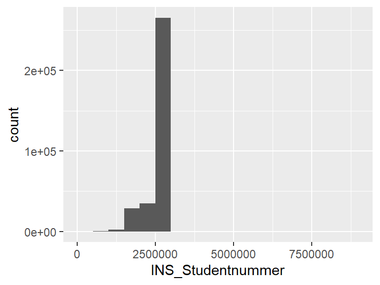

## INS_Inschrijvingsjaar

| Feature | Result |
| --- | --- |
| Variable type | numeric |
| Number of missing obs. | 0 (0 %) |
| Number of unique values | 13 |
| Median | 2017 |
| 1st and 3rd quartiles | 2014; 2020 |
| Min. and max. | 2010; 2022 |

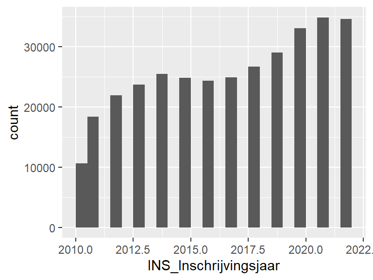

## INS_Inschrijvingsjaar_EOI

| Feature | Result |
| --- | --- |
| Variable type | numeric |
| Number of missing obs. | 1696 (0.51 %) |
| Number of unique values | 20 |
| Median | 2016 |
| 1st and 3rd quartiles | 2013; 2019 |
| Min. and max. | 2003; 2022 |

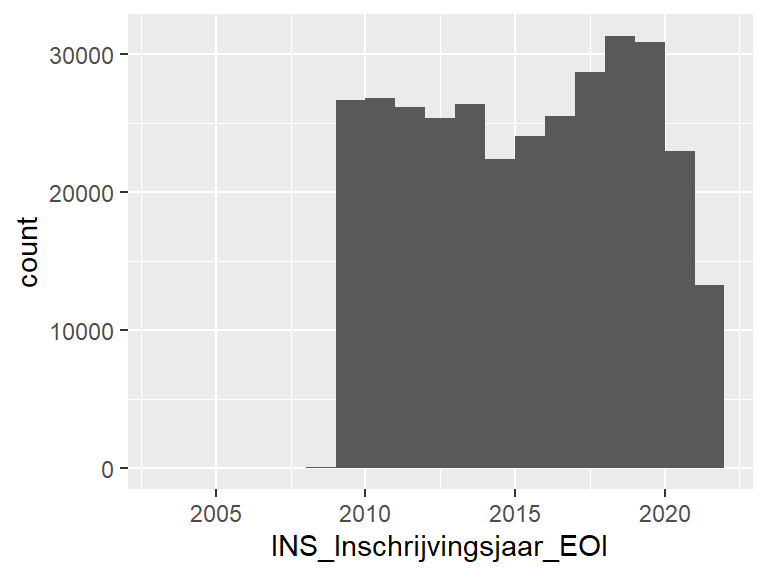

## INS_Studierichting_SAP_numeriek

| Feature | Result |
| --- | --- |
| Variable type | numeric |
| Number of missing obs. | 0 (0 %) |
| Number of unique values | 291 |
| Median | 50051118 |
| 1st and 3rd quartiles | 50046599; 50052304 |
| Min. and max. | 50043568; 52579738 |

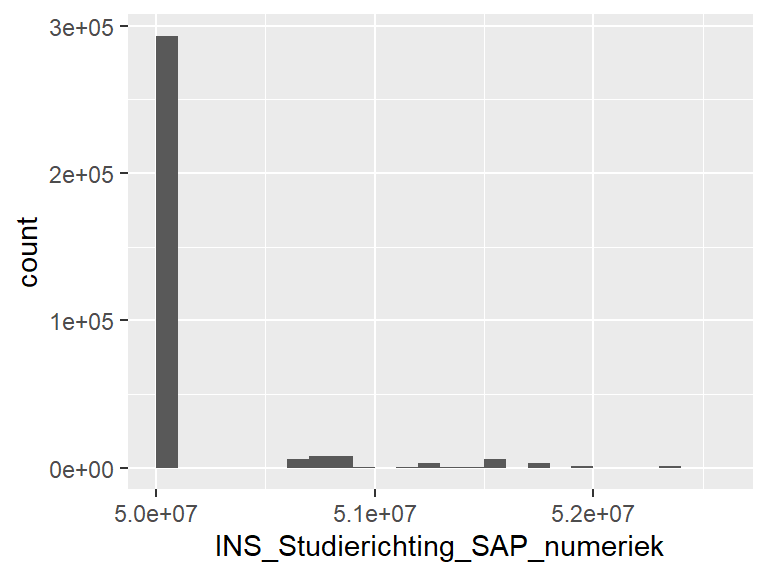

## INS_Soort_inschrijving_1CHO_code

| Feature | Result |
| --- | --- |
| Variable type | numeric |
| Number of missing obs. | 0 (0 %) |
| Number of unique values | 4 |
| Median | 1 |
| 1st and 3rd quartiles | 1; 1 |
| Min. and max. | 1; 4 |

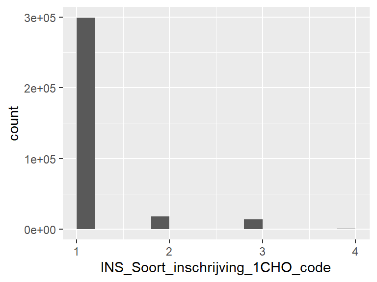

## INS_Soort_inschrijving_actuele_instelling

| Feature | Result |
| --- | --- |
| Variable type | numeric |
| Number of missing obs. | 0 (0 %) |
| Number of unique values | 4 |
| Median | 1 |
| 1st and 3rd quartiles | 1; 1 |
| Min. and max. | 1; 4 |

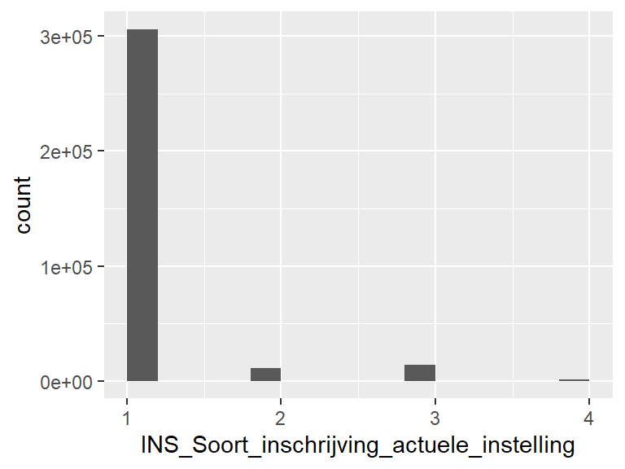

## INS_Opleidingsfase_actueel

| Feature | Result |
| --- | --- |
| Variable type | character |
| Number of missing obs. | 0 (0 %) |
| Number of unique values | 3 |
| Mode | “B” |

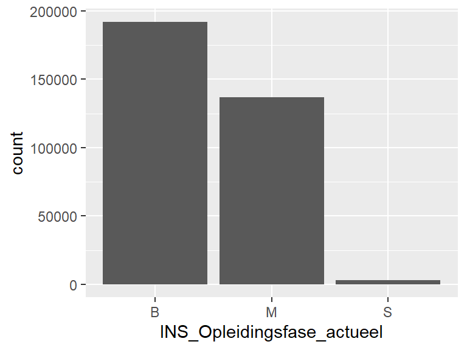

- Observed factor levels: "B", "M", "S".

## INS_Indicatie_actief_op_peildatum

| Feature | Result |
| --- | --- |
| Variable type | numeric |
| Number of missing obs. | 0 (0 %) |
| Number of unique values | 4 |
| Median | 1 |
| 1st and 3rd quartiles | 1; 1 |
| Min. and max. | 1; 4 |

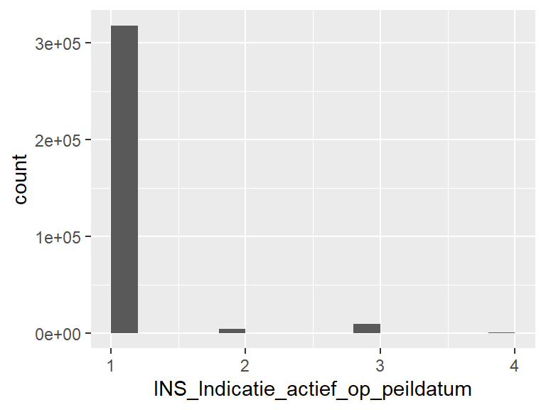

## OPL_Code_in_jaar

| Feature | Result |
| --- | --- |
| Variable type | numeric |
| Number of missing obs. | 0 (0 %) |
| Number of unique values | 211 |
| Median | 56860 |
| 1st and 3rd quartiles | 54999; 60644 |
| Min. and max. | 50007; 69333 |

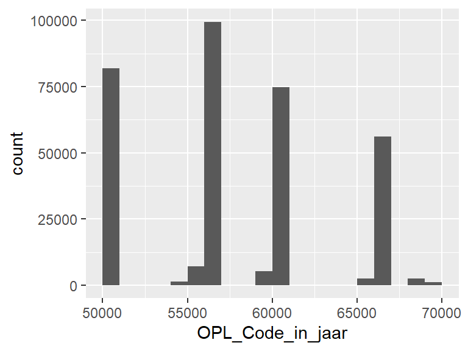

## INS_Opleidingsnaam_2002

| Feature | Result |
| --- | --- |
| Variable type | character |
| Number of missing obs. | 0 (0 %) |
| Number of unique values | 209 |
| Mode | “B Rechtsgeleerdheid” |

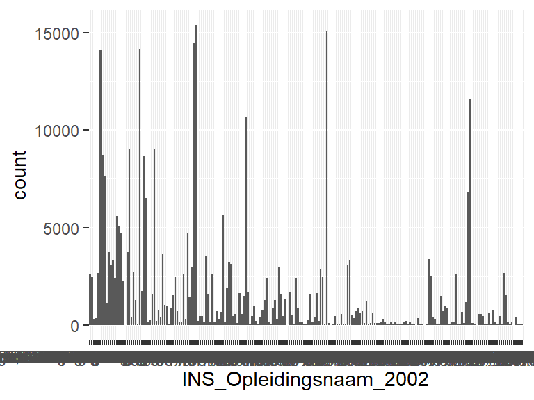

- Observed factor levels: "B Aarde, Economie en Duurzaamheid", "B Aardwetenschappen", "B Algemene Cultuurwetenschappen", "B Archeologie", "B Artificial Intelligence", …, "M Tinbergen Institute Research Master in Economics (joint degree)", "M TRANSPORT AND SUPPLY CHAIN MANAGEMENT", "M Visual Arts, Media and Architecture (research)", "M Wijsbegeerte", "M Wijsbegeerte van een Bepaald Wetenschapsgebied" (199 values omitted).

## INS_Indicatie_eerste_jaars_opleiding

| Feature | Result |
| --- | --- |
| Variable type | numeric |
| Number of missing obs. | 0 (0 %) |
| Number of unique values | 5 |
| Median | 2 |
| 1st and 3rd quartiles | 1; 2 |
| Min. and max. | 1; 5 |

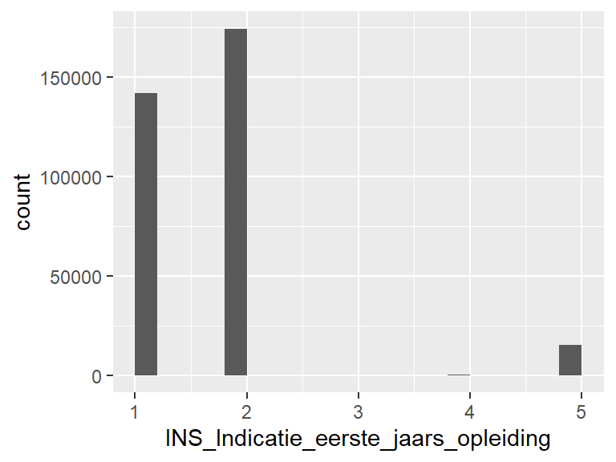

## INS_Indicatie_eerste_jaars_instelling

| Feature | Result |
| --- | --- |
| Variable type | numeric |
| Number of missing obs. | 0 (0 %) |
| Number of unique values | 5 |
| Median | 2 |
| 1st and 3rd quartiles | 1; 2 |
| Min. and max. | 1; 5 |

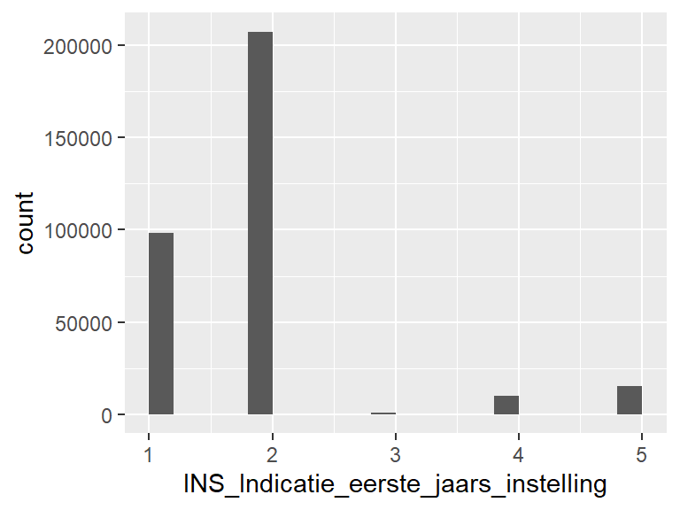

## INS_Indicatie_eerste_jaars_opleiding_en_instelling

| Feature | Result |
| --- | --- |
| Variable type | numeric |
| Number of missing obs. | 0 (0 %) |
| Number of unique values | 3 |
| Median | 2 |
| 1st and 3rd quartiles | 1; 2 |
| Min. and max. | 1; 5 |

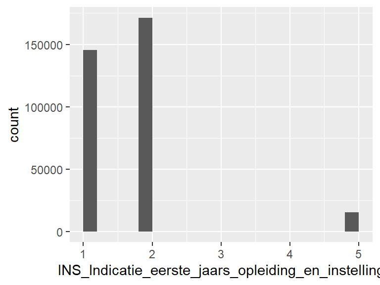

## INS_Eerste_jaar_opleiding_en_instelling

| Feature | Result |
| --- | --- |
| Variable type | numeric |
| Number of missing obs. | 0 (0 %) |
| Number of unique values | 13 |
| Median | 2016 |
| 1st and 3rd quartiles | 2013; 2019 |
| Min. and max. | 2010; 2022 |

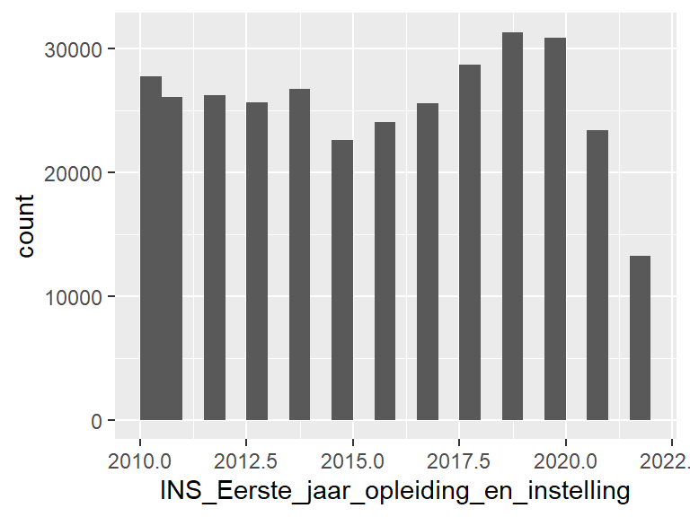

## INS_Eerste_jaar_hoger_onderwijs

| Feature | Result |
| --- | --- |
| Variable type | numeric |
| Number of missing obs. | 0 (0 %) |
| Number of unique values | 52 |
| Median | 2013 |
| 1st and 3rd quartiles | 2010; 2017 |
| Min. and max. | 1968; 2022 |

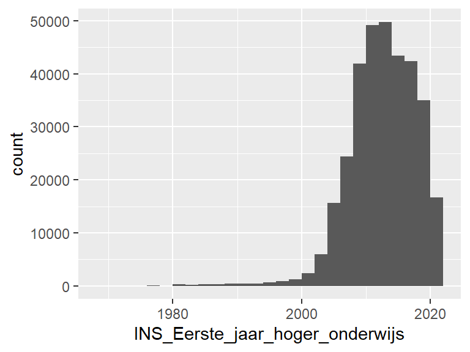

## INS_Eerste_jaar_soort_hoger_onderwijs

| Feature | Result |
| --- | --- |
| Variable type | numeric |
| Number of missing obs. | 0 (0 %) |
| Number of unique values | 52 |
| Median | 2014 |
| 1st and 3rd quartiles | 2011; 2018 |
| Min. and max. | 1968; 2022 |

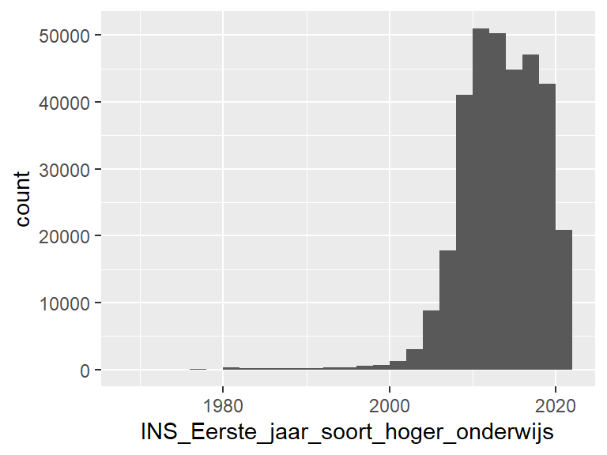

## INS_Vooropleiding_voor_HO_code

| Feature | Result |
| --- | --- |
| Variable type | numeric |
| Number of missing obs. | 0 (0 %) |
| Number of unique values | 46 |
| Median | 405 |
| 1st and 3rd quartiles | 402; 411 |
| Min. and max. | 0; 506 |

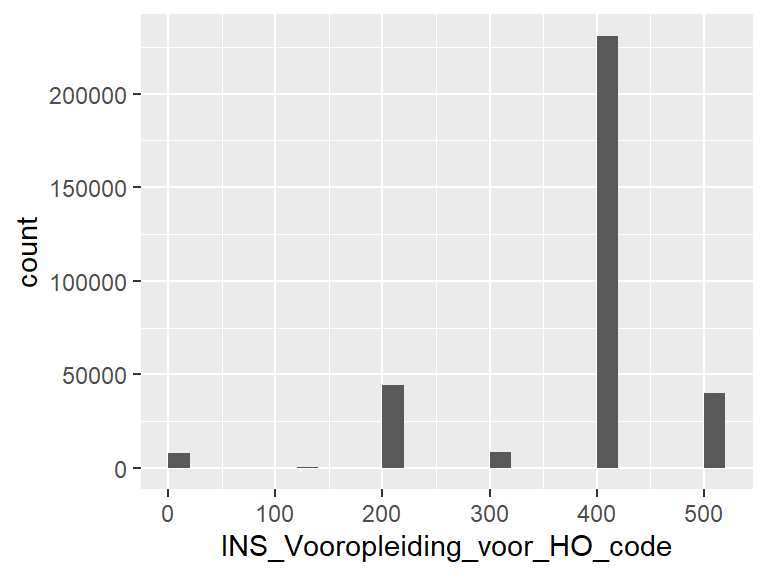

## INS_Vooropleiding_voor_HO_cat

| Feature | Result |
| --- | --- |
| Variable type | character |
| Number of missing obs. | 8036 (2.42 %) |
| Number of unique values | 6 |
| Mode | “vwo” |

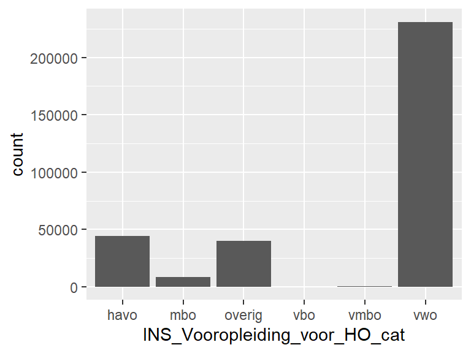

- Observed factor levels: "havo", "mbo", "overig", "vbo", "vmbo", "vwo".

## INS_Vooropleiding_voor_HO_jaar

| Feature | Result |
| --- | --- |
| Variable type | numeric |
| Number of missing obs. | 8244 (2.48 %) |
| Number of unique values | 60 |
| Median | 2012 |
| 1st and 3rd quartiles | 2009; 2016 |
| Min. and max. | 1960; 2021 |

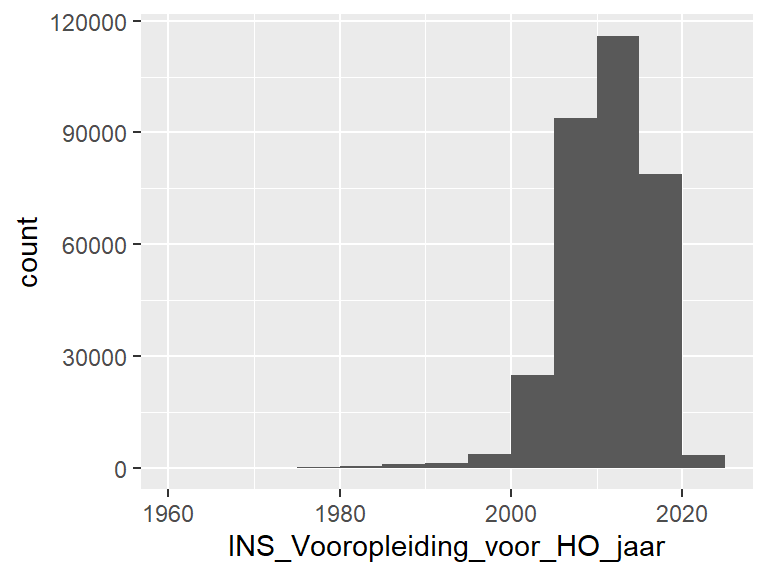

## INS_Vooropleiding_voor_HO_BRIN

| Feature | Result |
| --- | --- |
| Variable type | character |
| Number of missing obs. | 54298 (16.35 %) |
| Number of unique values | 657 |
| Mode | “25PZ” |

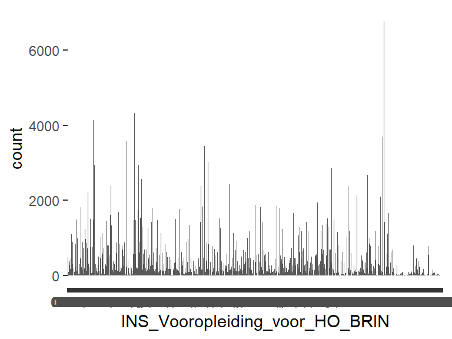

- Observed factor levels: "00AH", "00AQ", "00BD", "00CB", "00DI", …, "31KX", "31LV", "31LW", "31MD", "31RY" (647 values omitted).

## INS_Vooropleiding_binnen_HO_code

| Feature | Result |
| --- | --- |
| Variable type | numeric |
| Number of missing obs. | 0 (0 %) |
| Number of unique values | 70 |
| Median | 0 |
| 1st and 3rd quartiles | 0; 903 |
| Min. and max. | 0; 1355 |

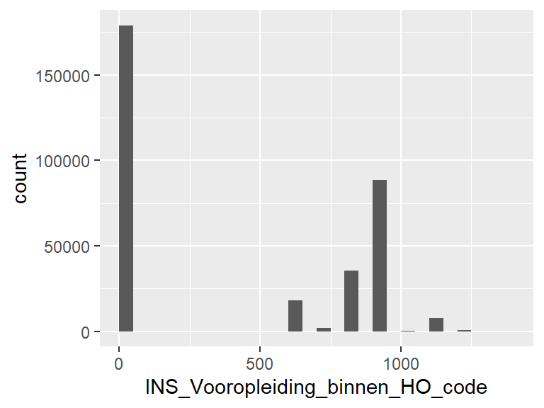

## INS_Vooropleiding_binnen_HO_cat

| Feature | Result |
| --- | --- |
| Variable type | character |
| Number of missing obs. | 179023 (53.89 %) |
| Number of unique values | 10 |
| Mode | “wo-ba” |

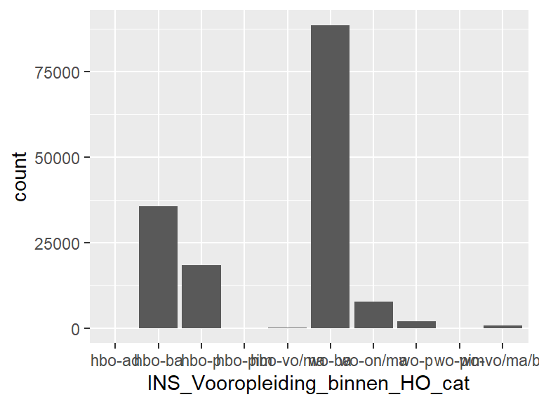

- Observed factor levels: "hbo-ad", "hbo-ba", "hbo-p", "hbo-pim", "hbo-vo/ma", "wo-ba", "wo-on/ma", "wo-p", "wo-pim", "wo-vo/ma/bf".

## INS_Vooropleiding_binnen_HO_jaar

| Feature | Result |
| --- | --- |
| Variable type | numeric |
| Number of missing obs. | 179023 (53.89 %) |
| Number of unique values | 52 |
| Median | 2014 |
| 1st and 3rd quartiles | 2011; 2017 |
| Min. and max. | 1967; 2021 |

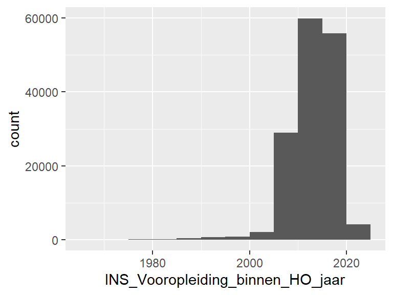

## INS_Vooropleiding_binnen_HO_BRIN

| Feature | Result |
| --- | --- |
| Variable type | character |
| Number of missing obs. | 181303 (54.58 %) |
| Number of unique values | 138 |
| Mode | “21PL” |

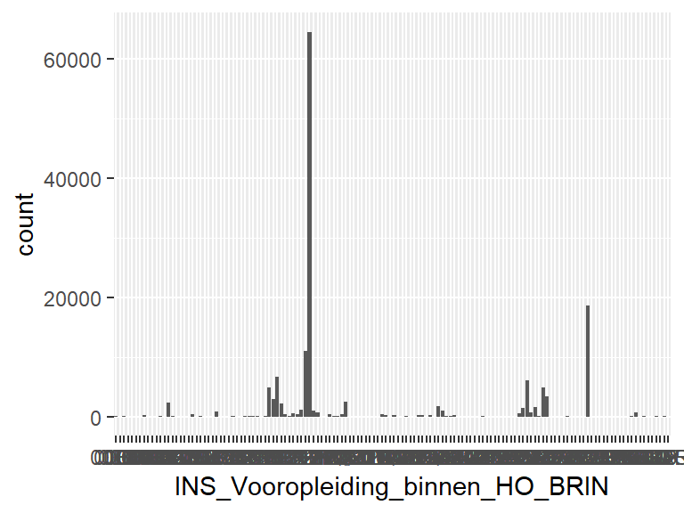

- Observed factor levels: "00BH", "00BM", "00DV", "00EY", "00IC", …, "30PB", "30TX", "30WG", "31FR", "31PT" (128 values omitted).

## INS_Hoogste_vooropleiding_code_1CHO

| Feature | Result |
| --- | --- |
| Variable type | numeric |
| Number of missing obs. | 0 (0 %) |
| Number of unique values | 104 |
| Median | 502 |
| 1st and 3rd quartiles | 405; 903 |
| Min. and max. | 0; 1355 |

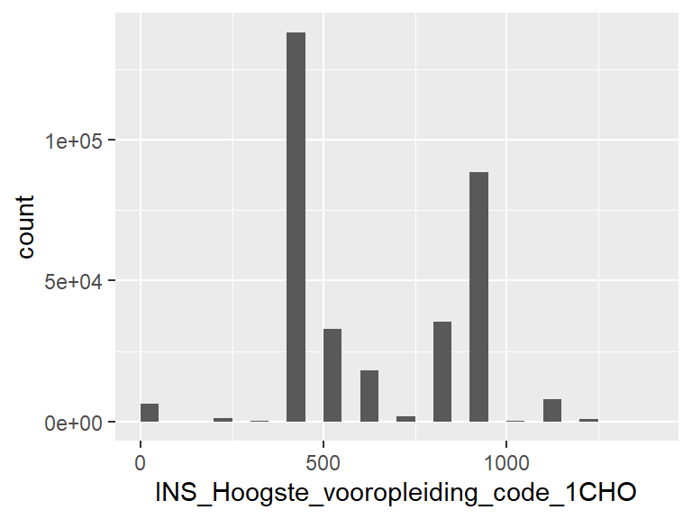

## INS_Hoogste_vooropleiding_cat

| Feature | Result |
| --- | --- |
| Variable type | character |
| Number of missing obs. | 6434 (1.94 %) |
| Number of unique values | 15 |
| Mode | “vwo” |

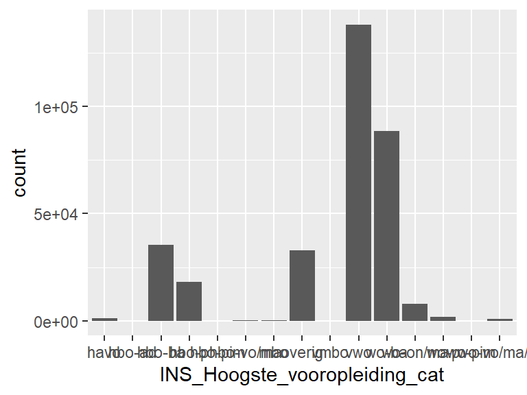

- Observed factor levels: "havo", "hbo-ad", "hbo-ba", "hbo-p", "hbo-pim", …, "wo-ba", "wo-on/ma", "wo-p", "wo-pim", "wo-vo/ma/bf" (5 values omitted).

## INS_Hoogste_vooropleiding_jaar_1CHO

| Feature | Result |
| --- | --- |
| Variable type | numeric |
| Number of missing obs. | 6619 (1.99 %) |
| Number of unique values | 54 |
| Median | 2014 |
| 1st and 3rd quartiles | 2011; 2017 |
| Min. and max. | 1967; 2021 |

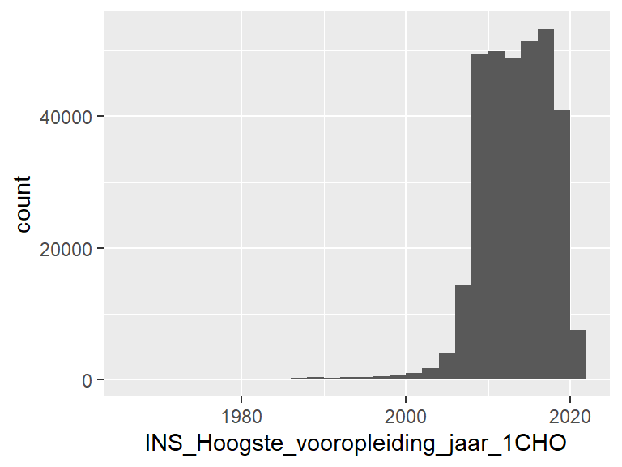

## INS_Hoogste_vooropleiding_BRIN_1CHO

| Feature | Result |
| --- | --- |
| Variable type | character |
| Number of missing obs. | 43203 (13.01 %) |
| Number of unique values | 725 |
| Mode | “21PL” |

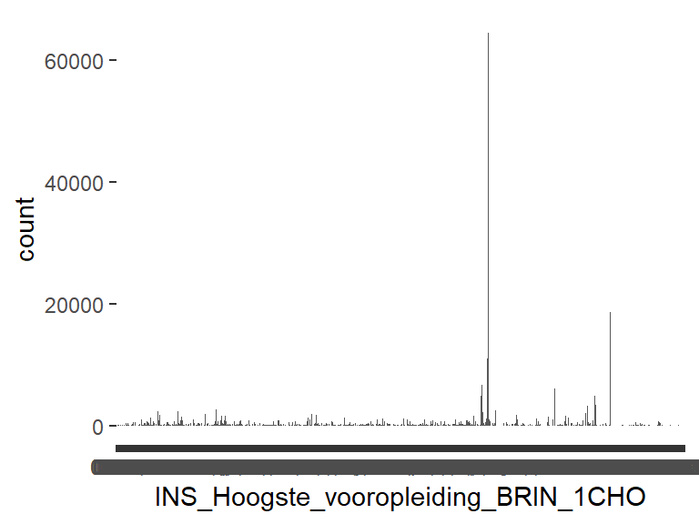

- Observed factor levels: "00AH", "00AQ", "00BD", "00BH", "00BM", …, "31LV", "31LW", "31MD", "31PT", "31RY" (715 values omitted).

## INS_Verblijfsjaren_hoger_onderwijs

| Feature | Result |
| --- | --- |
| Variable type | integer |
| Number of missing obs. | 14055 (4.23 %) |
| Number of unique values | 39 |
| Median | 4 |
| 1st and 3rd quartiles | 2; 6 |
| Min. and max. | 1; 39 |

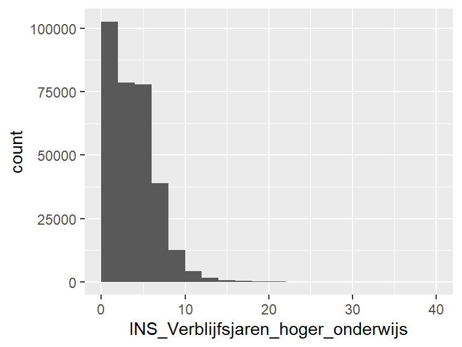

## INS_Verblijfsjaren_wetenschappelijk_onderwijs

| Feature | Result |
| --- | --- |
| Variable type | integer |
| Number of missing obs. | 14055 (4.23 %) |
| Number of unique values | 39 |
| Median | 3 |
| 1st and 3rd quartiles | 2; 5 |
| Min. and max. | 1; 39 |

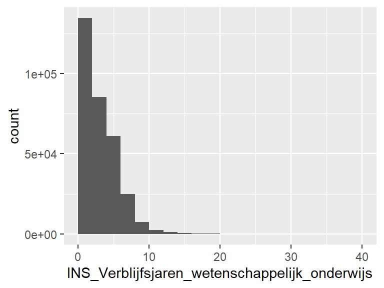

## INS_Inclusief_UvA

| Feature | Result |
| --- | --- |
| Variable type | logical |
| Number of missing obs. | 0 (0 %) |
| Number of unique values | 2 |
| Mode | “FALSE” |

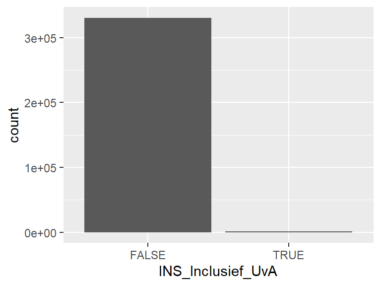

## INS_Premaster

- The variable only takes one (non-missing) value: "P". The variable contains 95.89 % missing observations.

## INS_Hoogste_vooropleiding_binnen_HO_code

| Feature | Result |
| --- | --- |
| Variable type | integer |
| Number of missing obs. | 179023 (53.89 %) |
| Number of unique values | 1229 |
| Median | 50700 |
| 1st and 3rd quartiles | 34616; 56604 |
| Min. and max. | 520; 81000 |

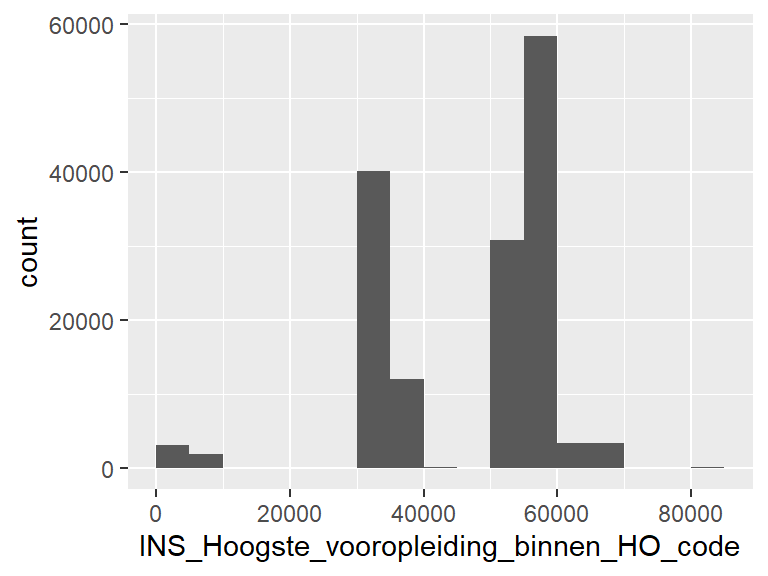

## INS_Faculteit

| Feature | Result |
| --- | --- |
| Variable type | character |
| Number of missing obs. | 0 (0 %) |
| Number of unique values | 10 |
| Mode | “BETA” |

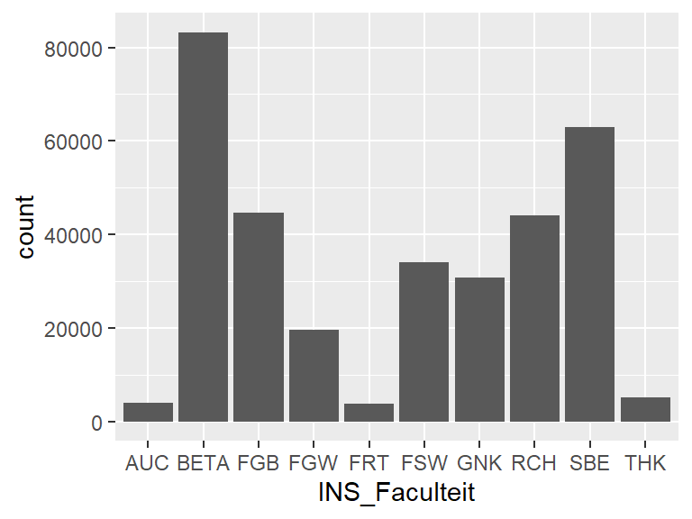

- Observed factor levels: "AUC", "BETA", "FGB", "FGW", "FRT", "FSW", "GNK", "RCH", "SBE", "THK".

## INS_Opleidingsvorm

| Feature | Result |
| --- | --- |
| Variable type | numeric |
| Number of missing obs. | 0 (0 %) |
| Number of unique values | 3 |
| Median | 1 |
| 1st and 3rd quartiles | 1; 1 |
| Min. and max. | 1; 3 |

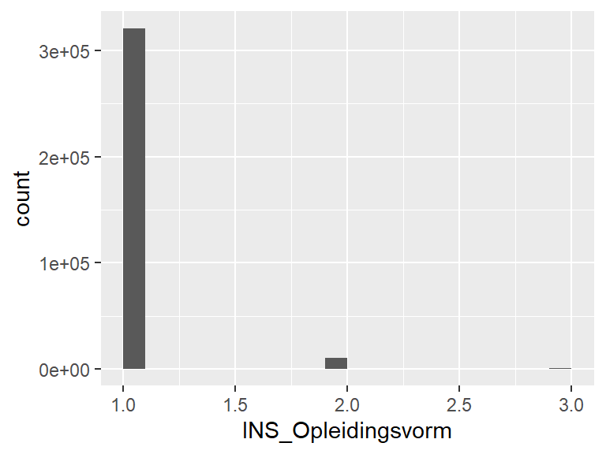

## INS_Code_bekostiging

| Feature | Result |
| --- | --- |
| Variable type | character |
| Number of missing obs. | 0 (0 %) |
| Number of unique values | 4 |
| Mode | “J” |

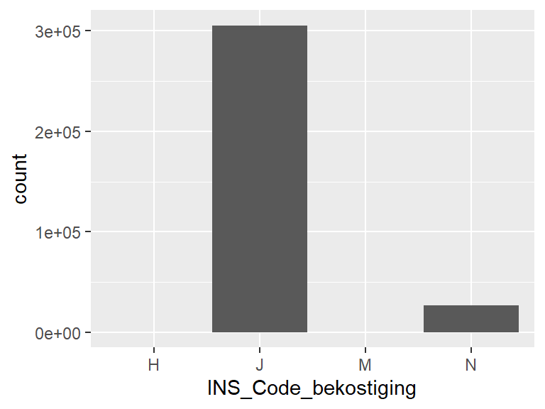

- Observed factor levels: "H", "J", "M", "N".

## INS_Code_examenresultaat

| Feature | Result |
| --- | --- |
| Variable type | numeric |
| Number of missing obs. | 256616 (77.25 %) |
| Number of unique values | 3 |
| Median | 1 |
| 1st and 3rd quartiles | 1; 1 |
| Min. and max. | 1; 9 |

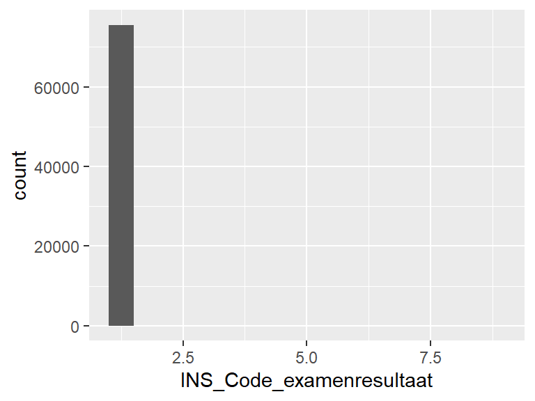

## INS_Opleidingscode_CROHO

| Feature | Result |
| --- | --- |
| Variable type | numeric |
| Number of missing obs. | 5429 (1.63 %) |
| Number of unique values | 7 |
| Median | 6 |
| 1st and 3rd quartiles | 5; 8 |
| Min. and max. | 1; 9 |

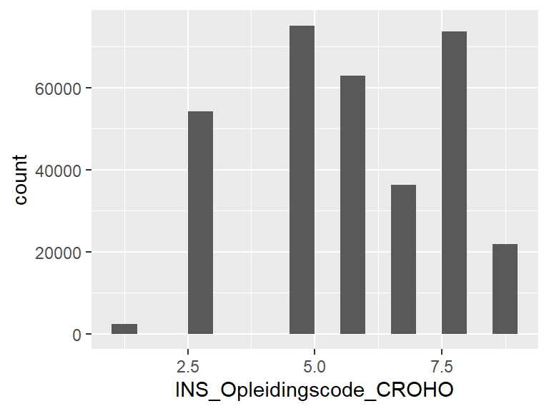

## INS_Code_beeindiging_inschrijving

| Feature | Result |
| --- | --- |
| Variable type | numeric |
| Number of missing obs. | 0 (0 %) |
| Number of unique values | 4 |
| Median | 0 |
| 1st and 3rd quartiles | 0; 0 |
| Min. and max. | 0; 9 |

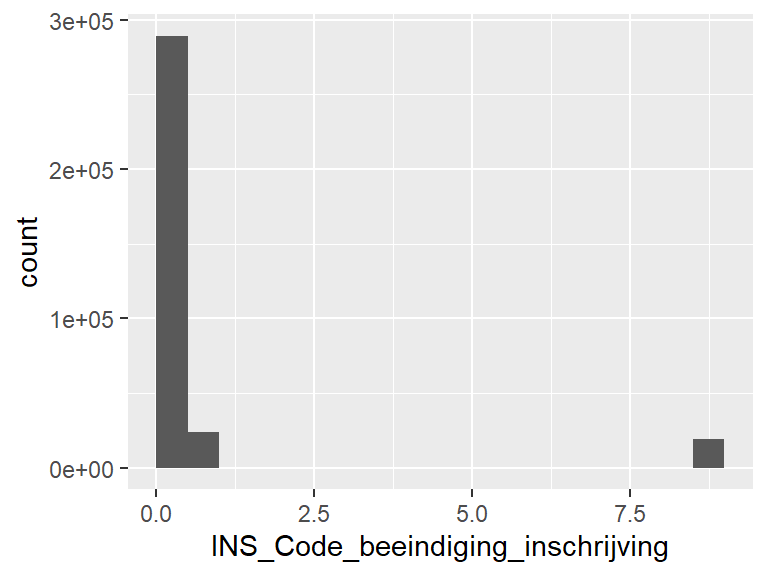

## INS_Type_onderwijs

| Feature | Result |
| --- | --- |
| Variable type | character |
| Number of missing obs. | 0 (0 %) |
| Number of unique values | 3 |
| Mode | “ba” |

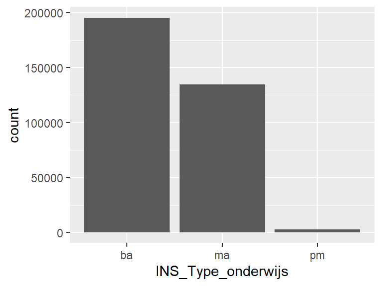

- Observed factor levels: "ba", "ma", "pm".

## INS_Diplomajaar

| Feature | Result |
| --- | --- |
| Variable type | numeric |
| Number of missing obs. | 256616 (77.25 %) |
| Number of unique values | 14 |
| Median | 2017 |
| 1st and 3rd quartiles | 2014; 2019 |
| Min. and max. | 2009; 2022 |

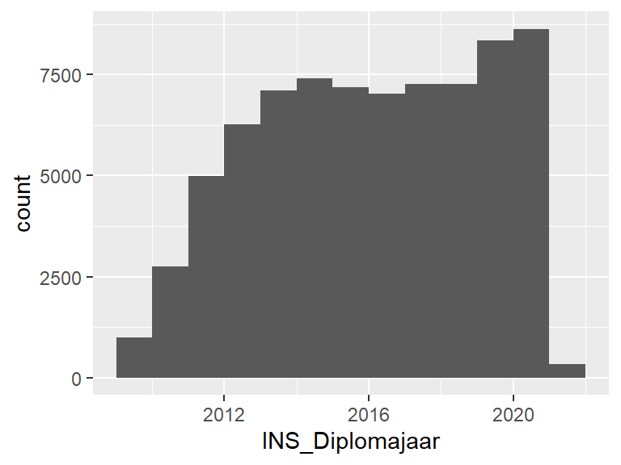

## INS_Diploma_opleidingsfase

| Feature | Result |
| --- | --- |
| Variable type | character |
| Number of missing obs. | 256616 (77.25 %) |
| Number of unique values | 3 |
| Mode | “M” |

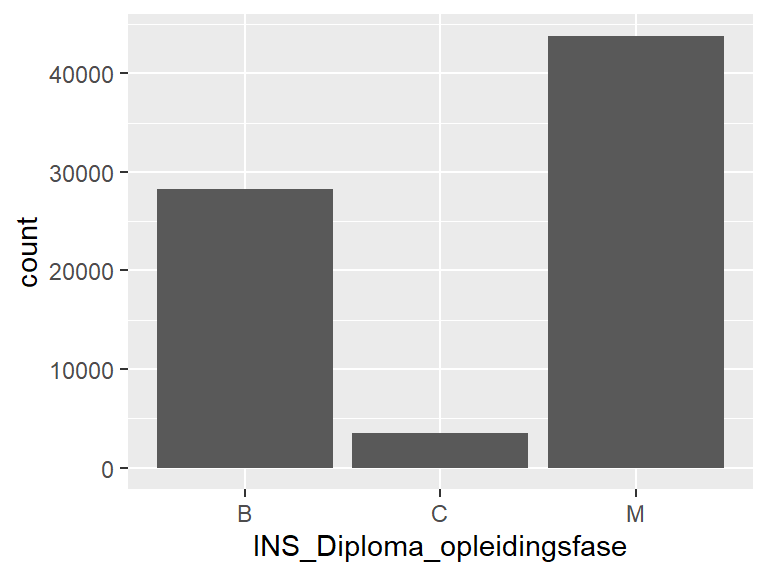

- Observed factor levels: "B", "C", "M".

## INS_Diploma_eerste

| Feature | Result |
| --- | --- |
| Variable type | numeric |
| Number of missing obs. | 256616 (77.25 %) |
| Number of unique values | 2 |
| Median | 2 |
| 1st and 3rd quartiles | 1; 2 |
| Min. and max. | 1; 2 |

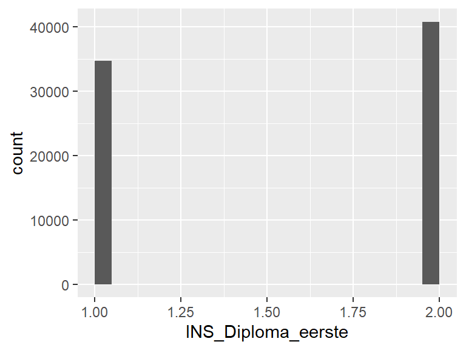

## INS_Diploma_eerste_in_categorie

| Feature | Result |
| --- | --- |
| Variable type | numeric |
| Number of missing obs. | 256616 (77.25 %) |
| Number of unique values | 6 |
| Median | 5 |
| 1st and 3rd quartiles | 3; 5 |
| Min. and max. | 3; 10 |

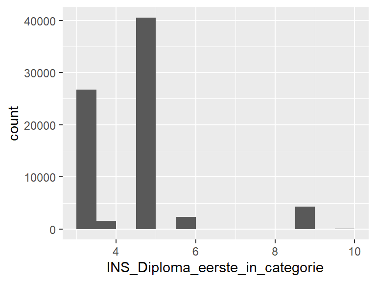

## INS_Diploma_eerste_in_categorie_hoofd_neven

| Feature | Result |
| --- | --- |
| Variable type | numeric |
| Number of missing obs. | 256616 (77.25 %) |
| Number of unique values | 6 |
| Median | 5 |
| 1st and 3rd quartiles | 3; 5 |
| Min. and max. | 3; 10 |

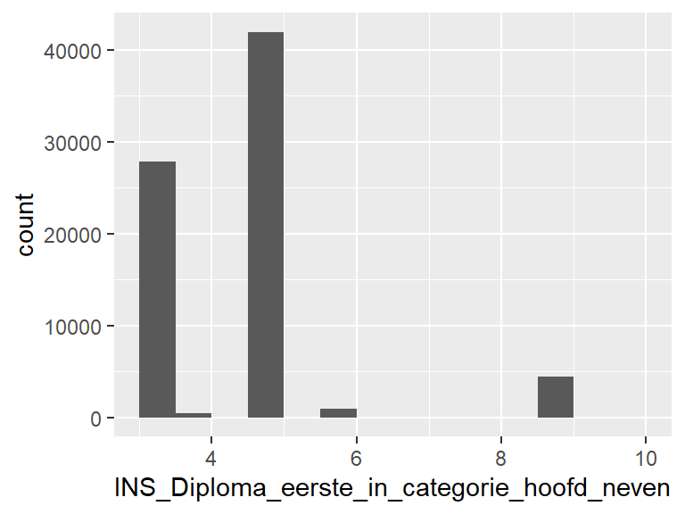

## INS_Diploma_eerste_bij_instelling_hoofd_neven

| Feature | Result |
| --- | --- |
| Variable type | numeric |
| Number of missing obs. | 256616 (77.25 %) |
| Number of unique values | 6 |
| Median | 5 |
| 1st and 3rd quartiles | 3; 5 |
| Min. and max. | 3; 10 |

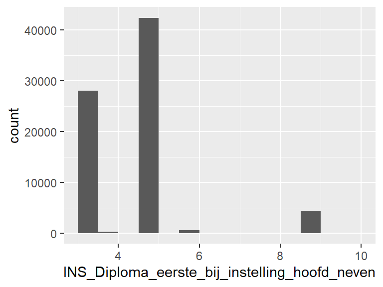

## DEM_Geslacht

| Feature | Result |
| --- | --- |
| Variable type | character |
| Number of missing obs. | 0 (0 %) |
| Number of unique values | 3 |
| Mode | “V” |

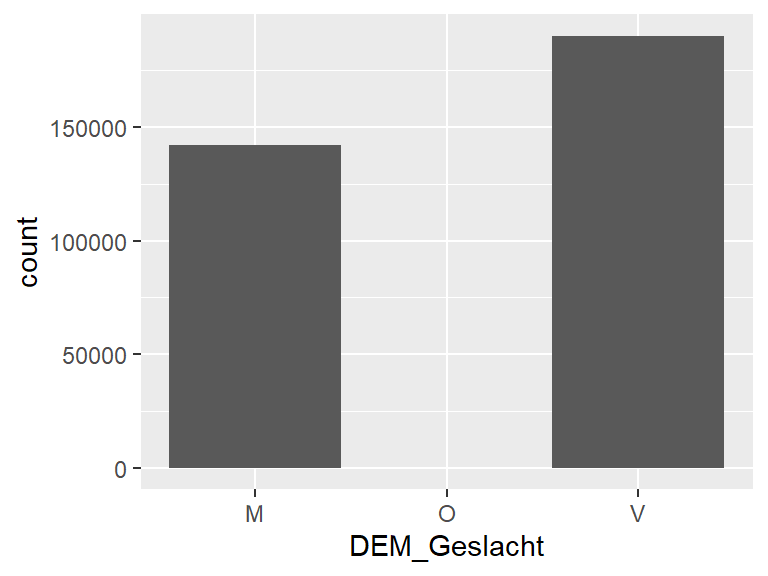

- Observed factor levels: "M", "O", "V".

## DEM_Leeftijd_peildatum_1_oktober

| Feature | Result |
| --- | --- |
| Variable type | numeric |
| Number of missing obs. | 0 (0 %) |
| Number of unique values | 66 |
| Median | 22 |
| 1st and 3rd quartiles | 20; 24 |
| Min. and max. | 15; 81 |

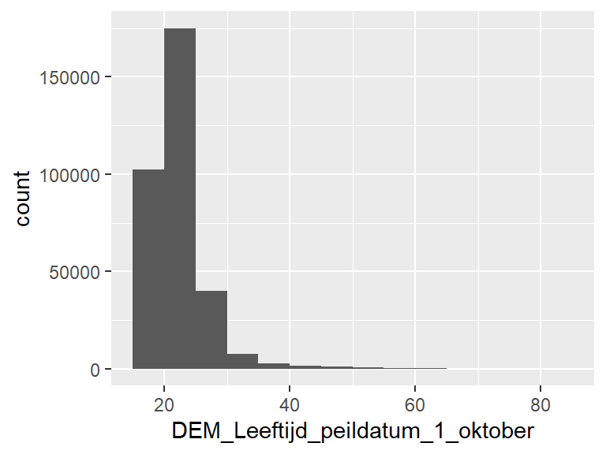

## DEM_Leeftijd_peildatum_1_jan

| Feature | Result |
| --- | --- |
| Variable type | numeric |
| Number of missing obs. | 0 (0 %) |
| Number of unique values | 66 |
| Median | 22 |
| 1st and 3rd quartiles | 20; 25 |
| Min. and max. | 15; 81 |

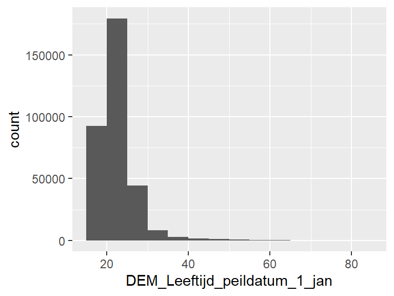

## DEM_Nationaliteit_1

| Feature | Result |
| --- | --- |
| Variable type | numeric |
| Number of missing obs. | 151 (0.05 %) |
| Number of unique values | 148 |
| Median | 1 |
| 1st and 3rd quartiles | 1; 1 |
| Min. and max. | 1; 499 |

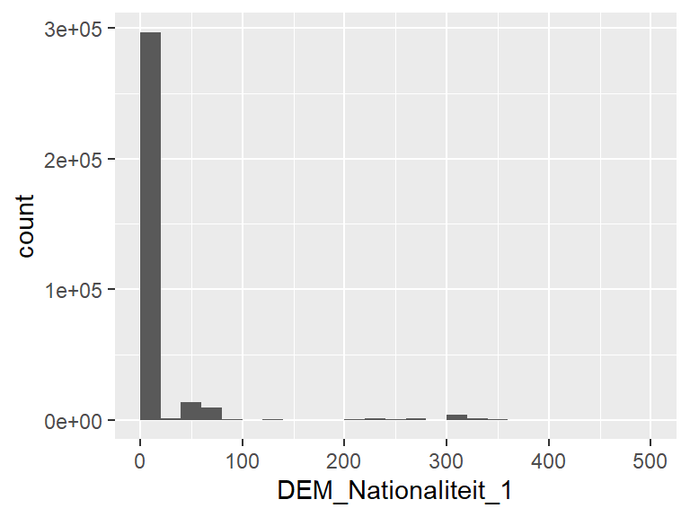

## DEM_Nationaliteit_2

| Feature | Result |
| --- | --- |
| Variable type | numeric |
| Number of missing obs. | 282676 (85.1 %) |
| Number of unique values | 158 |
| Median | 131 |
| 1st and 3rd quartiles | 112; 322 |
| Min. and max. | 27; 499 |

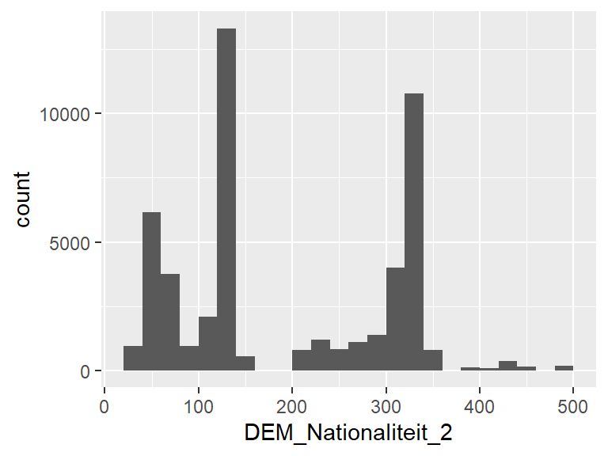

## DEM_Nationaliteit_3

| Feature | Result |
| --- | --- |
| Variable type | integer |
| Number of missing obs. | 331495 (99.79 %) |
| Number of unique values | 59 |
| Median | 307 |
| 1st and 3rd quartiles | 131; 339 |
| Min. and max. | 29; 500 |

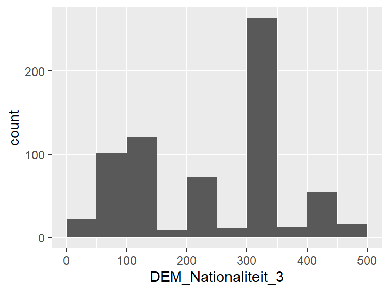

## INS_Postcode_student_1okt_peildatum

| Feature | Result |
| --- | --- |
| Variable type | integer |
| Number of missing obs. | 1869 (0.56 %) |
| Number of unique values | 2874 |
| Median | 1185 |
| 1st and 3rd quartiles | 1073; 2312 |
| Min. and max. | 10; 9988 |

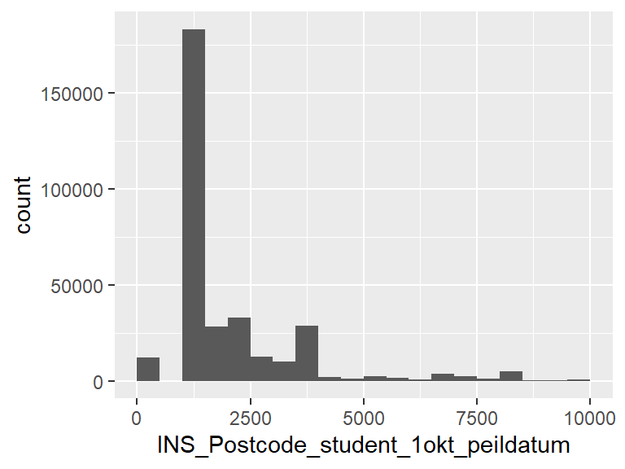

## INS_Vooropleiding_voor_HO_gem_cijfer

| Feature | Result |
| --- | --- |
| Variable type | numeric |
| Number of missing obs. | 90764 (27.32 %) |
| Number of unique values | 38 |
| Median | 66 |
| 1st and 3rd quartiles | 64; 70 |
| Min. and max. | 57; 95 |

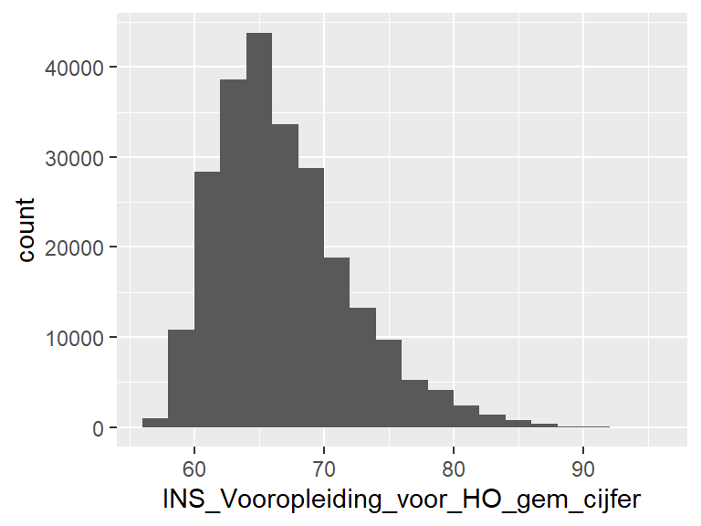

## INS_Datum_inschrijving

| Feature | Result |
| --- | --- |
| Variable type | Date |
| Number of missing obs. | 0 (0 %) |
| Number of unique values | 150 |
| Mode | “2022-09-01” |
| Min. and max. | 2010-09-01; 2023-02-01 |
| 1st and 3rd quartiles | 2014-09-01; 2020-09-01 |

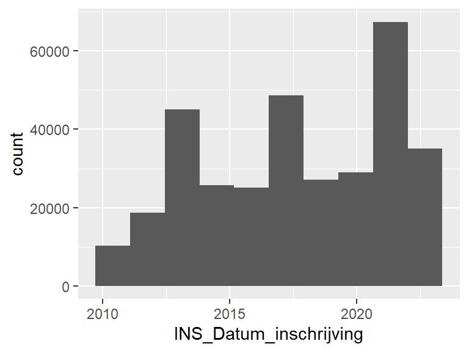

## INS_Datum_uitschrijving

| Feature | Result |
| --- | --- |
| Variable type | Date |
| Number of missing obs. | 0 (0 %) |
| Number of unique values | 179 |
| Mode | “2023-08-31” |
| Min. and max. | 2010-09-30; 2023-08-31 |
| 1st and 3rd quartiles | 2015-08-31; 2021-08-31 |

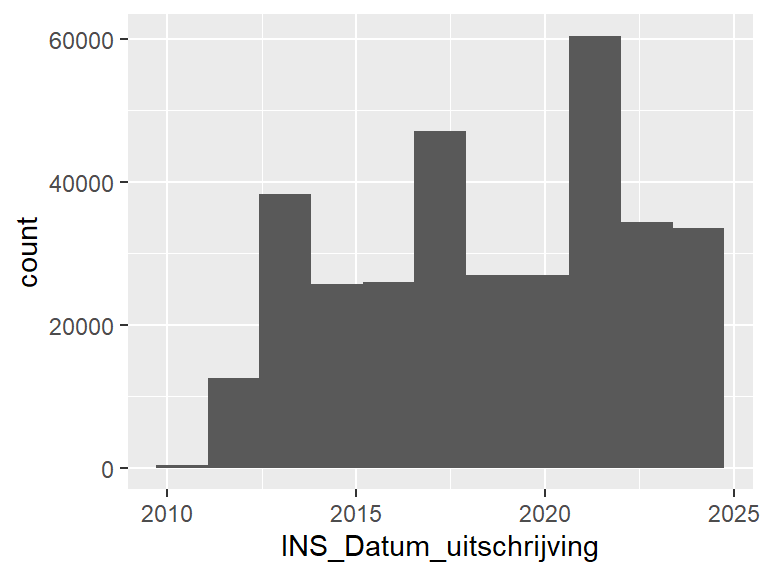

## INS_Verblijfsjaar_type_onderwijs_binnen_HO

| Feature | Result |
| --- | --- |
| Variable type | numeric |
| Number of missing obs. | 14055 (4.23 %) |
| Number of unique values | 24 |
| Median | 2 |
| 1st and 3rd quartiles | 1; 3 |
| Min. and max. | 1; 26 |

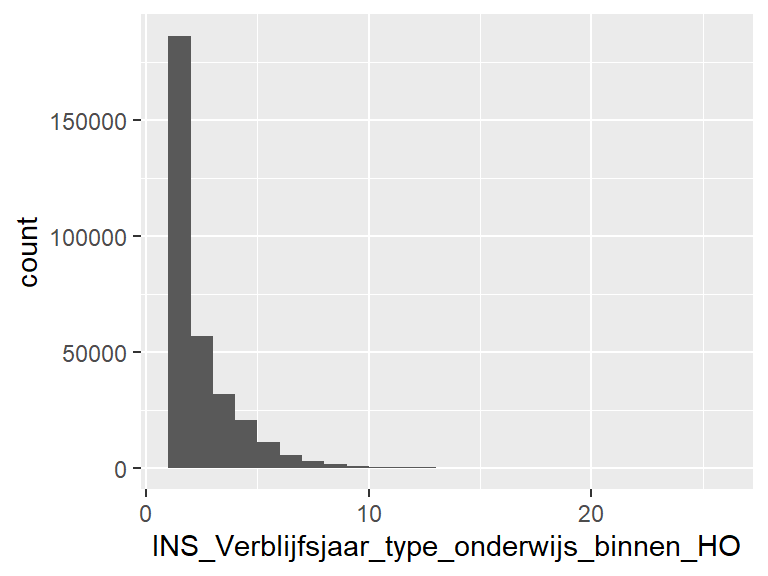

## INS_Postcode_student_voor_HO

| Feature | Result |
| --- | --- |
| Variable type | integer |
| Number of missing obs. | 55625 (16.75 %) |
| Number of unique values | 3288 |
| Median | 2141 |
| 1st and 3rd quartiles | 1383; 3824 |
| Min. and max. | 10; 9997 |

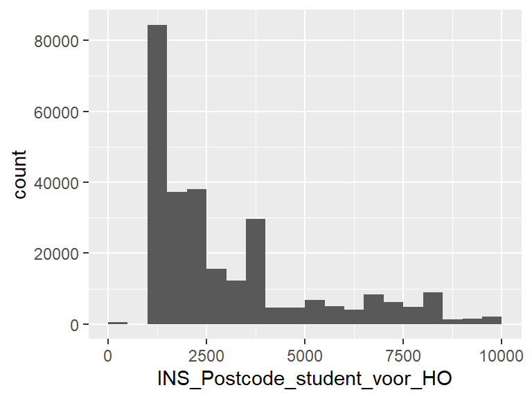

## INS_Maand_inschrijving_van

| Feature | Result |
| --- | --- |
| Variable type | numeric |
| Number of missing obs. | 0 (0 %) |
| Number of unique values | 12 |
| Median | 9 |
| 1st and 3rd quartiles | 9; 9 |
| Min. and max. | 1; 12 |

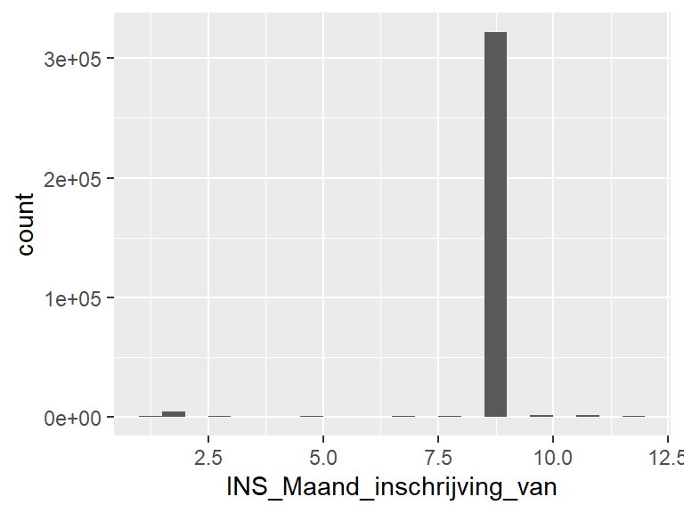

## INS_Maand_inschrijving_tot

| Feature | Result |
| --- | --- |
| Variable type | numeric |
| Number of missing obs. | 296492 (89.26 %) |
| Number of unique values | 12 |
| Median | 4 |
| 1st and 3rd quartiles | 2; 10 |
| Min. and max. | 1; 13 |

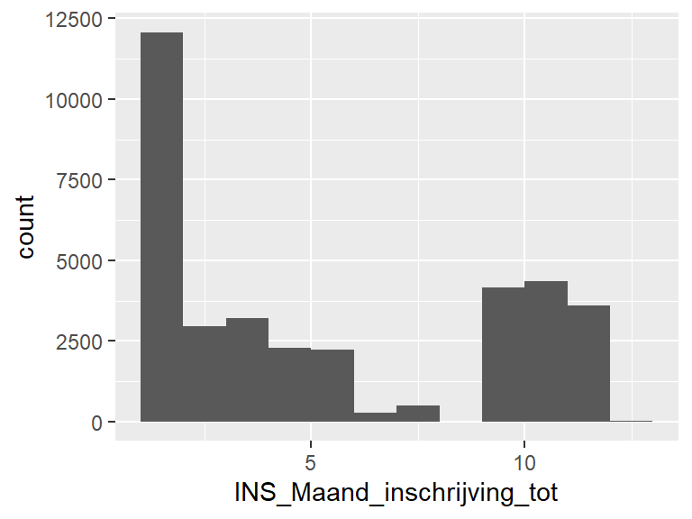

## INS_Maand_examenresultaat

| Feature | Result |
| --- | --- |
| Variable type | numeric |
| Number of missing obs. | 256616 (77.25 %) |
| Number of unique values | 12 |
| Median | 7 |
| 1st and 3rd quartiles | 6; 8 |
| Min. and max. | 1; 12 |

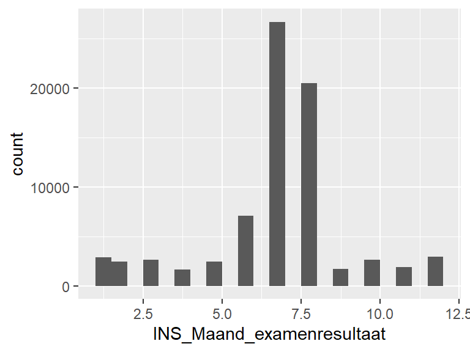

## INS_Croho_sub_onderdeel

| Feature | Result |
| --- | --- |
| Variable type | numeric |
| Number of missing obs. | 23 (0.01 %) |
| Number of unique values | 8 |
| Median | 9 |
| 1st and 3rd quartiles | 8; 11 |
| Min. and max. | 2; 20 |

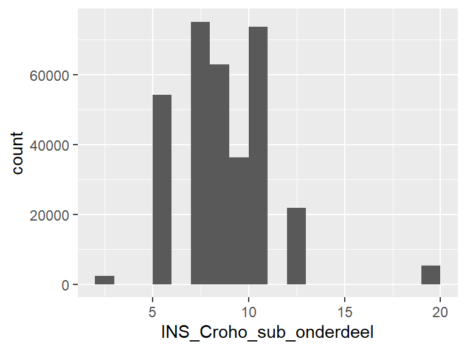

## INS_Verblijfsjaar_type_onderwijs

| Feature | Result |
| --- | --- |
| Variable type | numeric |
| Number of missing obs. | 14055 (4.23 %) |
| Number of unique values | 19 |
| Median | 2 |
| 1st and 3rd quartiles | 1; 3 |
| Min. and max. | 1; 19 |

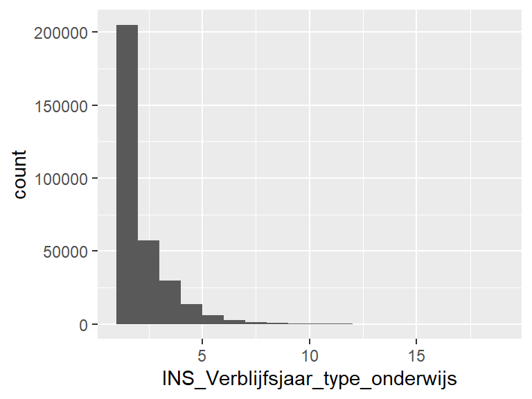